# Practical Machine Learning Course Project

Mikael Engmark

8/31/2017

## Background

6 participants have been asked to perform barbell lifts correctly and incorrectly in 5 different ways (A, B, C, D and E). The data is obtaining from accelerometers on the belt, forearm, arm, and dumbell of 6 participants.

## Exploring the data structure

The two data sets are imported

```r
data_raw <- read.csv("pml-training.csv",header = TRUE, na.strings = c ("","NA"))
data_test <- read.csv("pml-testing.csv",header = TRUE,na.strings = c("","NA"))
```

Investigating the structure of the provided data (input supressed for readability)

```
## 'data.frame':    19622 obs. of  160 variables:
##  $ X                       : int  1 2 3 4 5 6 7 8 9 10 ...
##  $ user_name               : Factor w/ 6 levels "adelmo","carlitos",..: 2 2 2 2 2 2 2 2 2 2 ...
##  $ raw_timestamp_part_1    : int  1323084231 1323084231 1323084231 1323084232 1323084232 1323084232 1323084232 1323084232 1323084232 1323084232 ...
##  $ raw_timestamp_part_2    : int  788290 808298 820366 120339 196328 304277 368296 440390 484323 484434 ...
##  $ cvtd_timestamp          : Factor w/ 20 levels "02/12/2011 13:32",..: 9 9 9 9 9 9 9 9 9 9 ...
##  $ new_window              : Factor w/ 2 levels "no","yes": 1 1 1 1 1 1 1 1 1 1 ...
##  $ num_window              : int  11 11 11 12 12 12 12 12 12 12 ...
##  $ roll_belt               : num  1.41 1.41 1.42 1.48 1.48 1.45 1.42 1.42 1.43 1.45 ...
##  $ pitch_belt              : num  8.07 8.07 8.07 8.05 8.07 8.06 8.09 8.13 8.16 8.17 ...
##  $ yaw_belt                : num  -94.4 -94.4 -94.4 -94.4 -94.4 -94.4 -94.4 -94.4 -94.4 -94.4 ...
##  $ total_accel_belt        : int  3 3 3 3 3 3 3 3 3 3 ...
##  $ kurtosis_roll_belt      : Factor w/ 396 levels "-0.016850","-0.021024",..: NA NA NA NA NA NA NA NA NA NA ...
##  $ kurtosis_picth_belt     : Factor w/ 316 levels "-0.021887","-0.060755",..: NA NA NA NA NA NA NA NA NA NA ...
##  $ kurtosis_yaw_belt       : Factor w/ 1 level "#DIV/0!": NA NA NA NA NA NA NA NA NA NA ...
```

[output cut: 86 more lines]

The training data contains 160 columns of which one is the outcome / how the exercise is performed (classe). The first column seams to be the row number whereas the following 6 columns contains data on how the data was collected - such as the name of the person, parts of a time stamp, and 2 apparently related “window” variables. The time should not be a relevant variable for the application of the model. Also, aiming at constructing a general model it is not rational to use the names of the 6 participants in the experiment (although the 20 observations in the test set are from the same 6 persons). Plots with the first two predictor candidates are made to get a feeling for the difference between the participants.

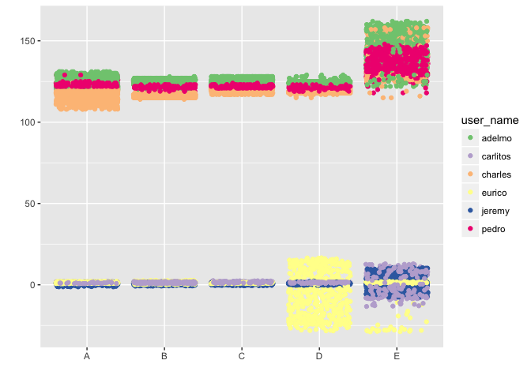

Predicter candidate ‘roll-belt’ vs classe and person

```r
ggplot(data_raw, aes(x=classe, y=roll_belt)) +
    geom_jitter(aes(color=user_name, fill=user_name)) +
    # facet_wrap(~ variable, scale="free_y") +
    scale_color_brewer(type = "qual") +
    scale_fill_brewer(type = "qual") +
    labs(x="", y="")
```

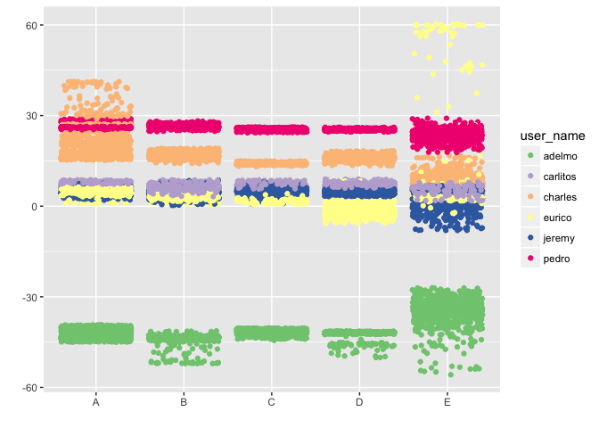

Predicter candidate ‘pitch_belt’ vs classe and person

```r
ggplot(data_raw, aes(x=classe, y=pitch_belt)) +
    geom_jitter(aes(color=user_name, fill=user_name)) +
    # facet_wrap(~ variable, scale="free_y") +
    scale_color_brewer(type = "qual") +
    scale_fill_brewer(type = "qual") +
    labs(x="", y="")
```

It appears that some of the different ways of performing barbell lifts result in more variance between oberservations from the same person. However, such variance cannot be used to predict outcome of single observations (the 20 test cases)… Using a prediction model based on descition threes such as random forrest, some parts of the algoritm might actually use clear differences between the individuals like Adelmo in ‘pitch-belt’ as part of their decitions (e.g. pitch-belt of -30 is always “E” - performed by Adelmo). This also means, that the name of the persons is redundant and may actually lead to overfitting of the model.

The names of the discussed variable are saved in a vector for trimming of the data set.

```r
Irrelevant_vars <- names(data_raw[,c(1:7)])
```

It is also evident from the str output that several of the remaining variables contains a lot of NA’s.

```
## [1] 100
```

[output not shown]

[output cut: 13 more lines]

```
##                    19216                    19216                    19216
##         max_roll_forearm        max_picth_forearm          max_yaw_forearm
##                    19216                    19216                    19216
##         min_roll_forearm        min_pitch_forearm          min_yaw_forearm
##                    19216                    19216                    19216
##   amplitude_roll_forearm  amplitude_pitch_forearm    amplitude_yaw_forearm
##                    19216                    19216                    19216
##        var_accel_forearm         avg_roll_forearm      stddev_roll_forearm
##                    19216                    19216                    19216
##         var_roll_forearm        avg_pitch_forearm     stddev_pitch_forearm
##                    19216                    19216                    19216
##        var_pitch_forearm          avg_yaw_forearm       stddev_yaw_forearm
##                    19216                    19216                    19216
##          var_yaw_forearm
##                    19216
```

```r
NA_vars <- names(no_NA_vars[no_NA_vars > 0])
vars_remove <- c(Irrelevant_vars, NA_vars)
data_red <- data_raw[, -which(names(data_raw) %in% vars_remove)]
```

## Creating data particions for training and validation of model

To estimate the in sample and out of sample error, the data set is slit in two using the caret package and 70 % of the data for the model building

```r
library(caret)
set.seed(2)
inTraining <- createDataPartition(data_red$classe, p = 0.70, list = FALSE)
training <- data_red[inTraining, ]
validation <- data_red[-inTraining, ]
```

## Looking for low variance parameter

Covariates with little variablity is not usefull predictors…

```r
nearZeroVar(training)
```

```
## integer(0)
```

All of the variable seams to contain information

## Building a random forrest model

To increase the speed of the model building process parallel computing is performed as described by https://github.com/lgreski/datasciencectacontent/blob/master/markdown/pml-randomForestPerformance.md

The model is performed using 5-fold cross-validation.

```r
library(parallel)
library(doParallel)
cluster <- makeCluster(detectCores() - 1) # Leave one core for OS
registerDoParallel(cluster)

# 5-fold cross-validation
fitControl <- trainControl(method = "repeatedcv",
                     number = 5,
                     classProbs=TRUE,
                     savePredictions="all",
                     allowParallel=TRUE)

model <- train(x = training[,-53],
               y = training$classe,
               tuneGrid = data.frame(mtry = c(1,2,3,4,5,6,10,15)), # The number of randomly selected features when each tree is created. The accuracy in each case is calculated based on fitControl
               method = "rf",
               trControl = fitControl)
stopCluster(cluster)
registerDoSEQ()
```

8 different random forrest models are prepared according to the tuneGrid specifications in the caret::train command. The final modal used 5 randomly selected features for tree construction to obtain the highest accuracy determined by 5-fold cross-validation.

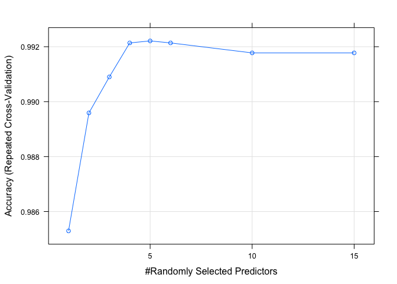

```r
plot(model)
```

```r
model$finalModel
```

```
##
## Call:
##  randomForest(x = x, y = y, mtry = param$mtry)
##                Type of random forest: classification
##                      Number of trees: 500
## No. of variables tried at each split: 5
##
##         OOB estimate of  error rate: 0.55%
## Confusion matrix:
##      A    B    C    D    E  class.error
## A 3904    1    0    0    1 0.0005120328
## B   12 2641    5    0    0 0.0063957863
## C    0   15 2378    3    0 0.0075125209
## D    0    0   30 2220    2 0.0142095915
## E    0    0    2    5 2518 0.0027722772
```

```r
save(model, file="barbell_lift_model.RData")
```

## Estimating the out-of-sample error

```r
validation_pred <- predict(model, validation)
confusionMatrix(validation_pred, validation$classe)
```

```
## Confusion Matrix and Statistics
##
##           Reference
## Prediction    A    B    C    D    E
##          A 1674    7    0    0    0
##          B    0 1131    6    0    0
##          C    0    1 1019   11    0
##          D    0    0    1  953    0
##          E    0    0    0    0 1082
##
## Overall Statistics
##
##                Accuracy : 0.9956
##                  95% CI : (0.9935, 0.9971)
##     No Information Rate : 0.2845
##     P-Value [Acc > NIR] : < 2.2e-16
##
##                   Kappa : 0.9944
##  Mcnemar's Test P-Value : NA
##
## Statistics by Class:
##
##                      Class: A Class: B Class: C Class: D Class: E
## Sensitivity            1.0000   0.9930   0.9932   0.9886   1.0000
## Specificity            0.9983   0.9987   0.9975   0.9998   1.0000
## Pos Pred Value         0.9958   0.9947   0.9884   0.9990   1.0000
## Neg Pred Value         1.0000   0.9983   0.9986   0.9978   1.0000
## Prevalence             0.2845   0.1935   0.1743   0.1638   0.1839
## Detection Rate         0.2845   0.1922   0.1732   0.1619   0.1839
## Detection Prevalence   0.2856   0.1932   0.1752   0.1621   0.1839
## Balanced Accuracy      0.9992   0.9959   0.9954   0.9942   1.0000
```

The out of sample error in terms of accuracy is 0.996 - wich is very, very good. I guess we are overfitting to the 6 participants in the experiment. I am not convinced that predicting other persons ways of performing barbell lifts are equally good by this model.

## Prediction of 20 test cases

Trimming the test data set containing 20 observations to only include the predictor variables and the classe variable (unknown here)

```r
data_test_red <- data_test[, -which(names(data_test) %in% vars_remove)]
test_results <- predict(model, data_test_red)
```